# Risk Factor Analysis

## Outcome Variable

**Outcome Variable:** haz

## Predictor Variables

**Intervention Variable:** single

**Adjustment Set:**

- arm
- W_mage
- meducyrs
- feducyrs
- W_mhtcm
- W_mwtkg
- W_mbmi
- delta_W_mage
- delta_meducyrs
- delta_feducyrs
- delta_W_mhtcm
- delta_W_mwtkg
- delta_W_mbmi

## Stratifying Variables

The analysis was stratified on these variable(s):

- agecat
- studyid
- country

## Data Summary

| agecat | studyid | country | single | n_cell | n | outcome_variable |
| --- | --- | --- | --- | --- | --- | --- |
| Birth | COHORTS | GUATEMALA | 0 | 719 | 767 | haz |
| Birth | COHORTS | GUATEMALA | 1 | 48 | 767 | haz |
| Birth | COHORTS | INDIA | 0 | 4771 | 4778 | haz |
| Birth | COHORTS | INDIA | 1 | 7 | 4778 | haz |
| Birth | COHORTS | PHILIPPINES | 0 | 2936 | 3010 | haz |
| Birth | COHORTS | PHILIPPINES | 1 | 74 | 3010 | haz |
| Birth | JiVitA-4 | BANGLADESH | 0 | 2814 | 2819 | haz |
| Birth | JiVitA-4 | BANGLADESH | 1 | 5 | 2819 | haz |
| Birth | MAL-ED | BANGLADESH | 0 | 231 | 231 | haz |
| Birth | MAL-ED | BANGLADESH | 1 | 0 | 231 | haz |
| Birth | MAL-ED | BRAZIL | 0 | 57 | 65 | haz |
| Birth | MAL-ED | BRAZIL | 1 | 8 | 65 | haz |
| Birth | MAL-ED | INDIA | 0 | 47 | 47 | haz |
| Birth | MAL-ED | INDIA | 1 | 0 | 47 | haz |
| Birth | MAL-ED | NEPAL | 0 | 27 | 27 | haz |
| Birth | MAL-ED | NEPAL | 1 | 0 | 27 | haz |
| Birth | MAL-ED | PERU | 0 | 209 | 233 | haz |
| Birth | MAL-ED | PERU | 1 | 24 | 233 | haz |
| Birth | MAL-ED | SOUTH AFRICA | 0 | 63 | 123 | haz |
| Birth | MAL-ED | SOUTH AFRICA | 1 | 60 | 123 | haz |
| Birth | MAL-ED | TANZANIA, UNITED REPUBLIC OF | 0 | 122 | 125 | haz |
| Birth | MAL-ED | TANZANIA, UNITED REPUBLIC OF | 1 | 3 | 125 | haz |
| Birth | PROBIT | BELARUS | 0 | 13351 | 13893 | haz |
| Birth | PROBIT | BELARUS | 1 | 542 | 13893 | haz |
| Birth | ZVITAMBO | ZIMBABWE | 0 | 12942 | 13817 | haz |
| Birth | ZVITAMBO | ZIMBABWE | 1 | 875 | 13817 | haz |
| 6 months | COHORTS | GUATEMALA | 0 | 826 | 893 | haz |
| 6 months | COHORTS | GUATEMALA | 1 | 67 | 893 | haz |
| 6 months | COHORTS | INDIA | 0 | 4962 | 4971 | haz |
| 6 months | COHORTS | INDIA | 1 | 9 | 4971 | haz |

[output cut: 54 more lines]

The following strata were considered:

- agecat: 24 months, studyid: COHORTS, country: GUATEMALA
- agecat: 24 months, studyid: COHORTS, country: INDIA
- agecat: 24 months, studyid: COHORTS, country: PHILIPPINES
- agecat: 24 months, studyid: JiVitA-4, country: BANGLADESH
- agecat: 24 months, studyid: MAL-ED, country: BANGLADESH
- agecat: 24 months, studyid: MAL-ED, country: BRAZIL
- agecat: 24 months, studyid: MAL-ED, country: INDIA
- agecat: 24 months, studyid: MAL-ED, country: NEPAL
- agecat: 24 months, studyid: MAL-ED, country: PERU
- agecat: 24 months, studyid: MAL-ED, country: SOUTH AFRICA
- agecat: 24 months, studyid: MAL-ED, country: TANZANIA, UNITED REPUBLIC OF
- agecat: 24 months, studyid: PROBIT, country: BELARUS
- agecat: 24 months, studyid: TanzaniaChild2, country: TANZANIA, UNITED REPUBLIC OF
- agecat: 24 months, studyid: ZVITAMBO, country: ZIMBABWE
- agecat: 6 months, studyid: COHORTS, country: GUATEMALA
- agecat: 6 months, studyid: COHORTS, country: INDIA
- agecat: 6 months, studyid: COHORTS, country: PHILIPPINES
- agecat: 6 months, studyid: Guatemala BSC, country: GUATEMALA
- agecat: 6 months, studyid: JiVitA-4, country: BANGLADESH
- agecat: 6 months, studyid: MAL-ED, country: BANGLADESH
- agecat: 6 months, studyid: MAL-ED, country: BRAZIL
- agecat: 6 months, studyid: MAL-ED, country: INDIA
- agecat: 6 months, studyid: MAL-ED, country: NEPAL
- agecat: 6 months, studyid: MAL-ED, country: PERU
- agecat: 6 months, studyid: MAL-ED, country: SOUTH AFRICA
- agecat: 6 months, studyid: MAL-ED, country: TANZANIA, UNITED REPUBLIC OF
- agecat: 6 months, studyid: PROBIT, country: BELARUS
- agecat: 6 months, studyid: TanzaniaChild2, country: TANZANIA, UNITED REPUBLIC OF
- agecat: 6 months, studyid: ZVITAMBO, country: ZIMBABWE
- agecat: Birth, studyid: COHORTS, country: GUATEMALA
- agecat: Birth, studyid: COHORTS, country: INDIA
- agecat: Birth, studyid: COHORTS, country: PHILIPPINES
- agecat: Birth, studyid: JiVitA-4, country: BANGLADESH
- agecat: Birth, studyid: MAL-ED, country: BANGLADESH
- agecat: Birth, studyid: MAL-ED, country: BRAZIL
- agecat: Birth, studyid: MAL-ED, country: INDIA
- agecat: Birth, studyid: MAL-ED, country: NEPAL
- agecat: Birth, studyid: MAL-ED, country: PERU
- agecat: Birth, studyid: MAL-ED, country: SOUTH AFRICA
- agecat: Birth, studyid: MAL-ED, country: TANZANIA, UNITED REPUBLIC OF
- agecat: Birth, studyid: PROBIT, country: BELARUS
- agecat: Birth, studyid: ZVITAMBO, country: ZIMBABWE

### Dropped Strata

Some strata were dropped due to rare outcomes:

- agecat: Birth, studyid: MAL-ED, country: BANGLADESH
- agecat: Birth, studyid: MAL-ED, country: INDIA
- agecat: Birth, studyid: MAL-ED, country: NEPAL
- agecat: Birth, studyid: MAL-ED, country: TANZANIA, UNITED REPUBLIC OF
- agecat: 6 months, studyid: MAL-ED, country: BANGLADESH
- agecat: 6 months, studyid: MAL-ED, country: INDIA
- agecat: 6 months, studyid: MAL-ED, country: NEPAL
- agecat: 24 months, studyid: MAL-ED, country: BANGLADESH
- agecat: 24 months, studyid: MAL-ED, country: INDIA
- agecat: 24 months, studyid: MAL-ED, country: NEPAL
- agecat: 24 months, studyid: TanzaniaChild2, country: TANZANIA, UNITED REPUBLIC OF

## Methods Detail

We’re interested in the causal parameters $E[Y_a]$ for all values of $a \in \mathcal{A}$. These parameters represent the mean outcome if, possibly contrary to fact, we intervened to set all units to have $A=a$. Under the randomization and positivity assumptions, these are identified by the statistical parameters $\psi_a=E_W[E_{Y|A,W}(Y|A=a,W)]$. In addition, we’re interested in the mean of $Y$, $E[Y]$ under no intervention (the observed mean). We will estimate these parameters by using SuperLearner to fit the relevant likelihood factors – $E_{Y|A,W}(Y|A=a,W)$ and $p(A=a|W)$, and then updating our likelihood fit using a joint TMLE.

For unadjusted analyses ($W=\{\}$), initial likelihoods were estimated using Lrnr_glm to estimate the simple $E(Y|A)$ and Lrnr_mean to estimate $p(A)$. For adjusted analyses, a small library containing Lrnr_glmnet, Lrnr_xgboost, and Lrnr_mean was used.

Having estimated these parameters, we will then use the delta method to estimate relative risks and attributable risks relative to a prespecified baseline level of $A$.

# Results Detail

## Results Plots

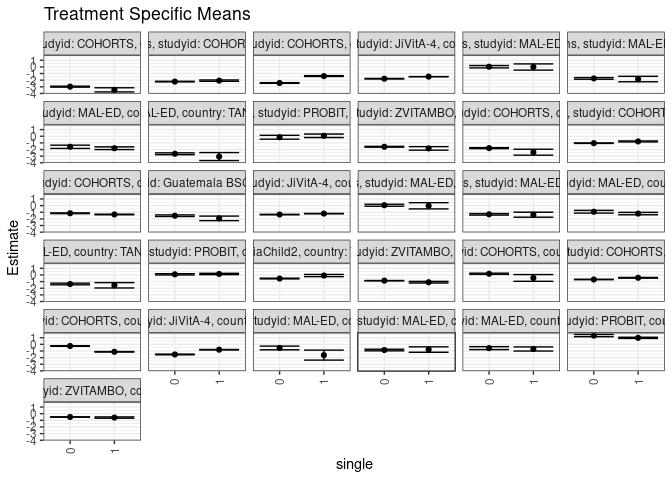

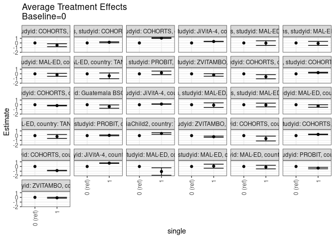

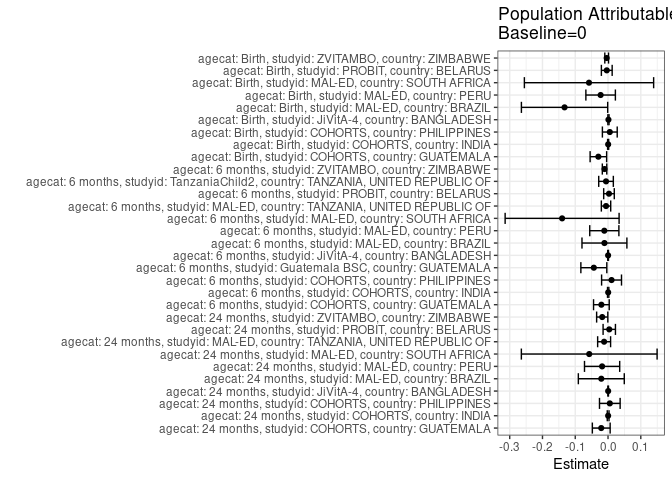

## Results Table

### Parameter: TSM

| agecat | studyid | country | intervention_level | baseline_level | estimate | ci_lower | ci_upper |
| --- | --- | --- | --- | --- | --- | --- | --- |
| Birth | COHORTS | GUATEMALA | 0 | NA | 0.1805804 | 0.0908273 | 0.2703335 |
| Birth | COHORTS | GUATEMALA | 1 | NA | -0.4480739 | -0.9568571 | 0.0607093 |
| Birth | COHORTS | INDIA | 0 | NA | -0.6778139 | -0.7115208 | -0.6441070 |
| Birth | COHORTS | INDIA | 1 | NA | -0.4242857 | -0.4784569 | -0.3701145 |
| Birth | COHORTS | PHILIPPINES | 0 | NA | -0.2519727 | -0.2981689 | -0.2057765 |
| Birth | COHORTS | PHILIPPINES | 1 | NA | -1.1240903 | -1.1583120 | -1.0898686 |
| Birth | JiVitA-4 | BANGLADESH | 0 | NA | -1.5248721 | -1.5752417 | -1.4745025 |
| Birth | JiVitA-4 | BANGLADESH | 1 | NA | -0.8080000 | -0.8384743 | -0.7775257 |
| Birth | MAL-ED | BRAZIL | 0 | NA | -0.5433333 | -0.8229128 | -0.2637539 |
| Birth | MAL-ED | BRAZIL | 1 | NA | -1.6212500 | -2.3756597 | -0.8668403 |
| Birth | MAL-ED | PERU | 0 | NA | -0.8602096 | -0.9813502 | -0.7390689 |
| Birth | MAL-ED | PERU | 1 | NA | -0.7863515 | -1.1959725 | -0.3767305 |
| Birth | MAL-ED | SOUTH AFRICA | 0 | NA | -0.5736629 | -0.7953880 | -0.3519379 |
| Birth | MAL-ED | SOUTH AFRICA | 1 | NA | -0.7013921 | -1.0125395 | -0.3902448 |
| Birth | PROBIT | BELARUS | 0 | NA | 1.3152767 | 1.1492048 | 1.4813485 |
| Birth | PROBIT | BELARUS | 1 | NA | 0.9754188 | 0.8892653 | 1.0615723 |
| Birth | ZVITAMBO | ZIMBABWE | 0 | NA | -0.4966436 | -0.5178810 | -0.4754061 |
| Birth | ZVITAMBO | ZIMBABWE | 1 | NA | -0.5865037 | -0.6834040 | -0.4896034 |
| 6 months | COHORTS | GUATEMALA | 0 | NA | -1.7886762 | -1.8613224 | -1.7160300 |
| 6 months | COHORTS | GUATEMALA | 1 | NA | -2.4028449 | -2.8491708 | -1.9565189 |
| 6 months | COHORTS | INDIA | 0 | NA | -1.0423478 | -1.0757913 | -1.0089044 |
| 6 months | COHORTS | INDIA | 1 | NA | -0.7833333 | -0.8545896 | -0.7120771 |
| 6 months | COHORTS | PHILIPPINES | 0 | NA | -1.1521898 | -1.2056878 | -1.0986918 |
| 6 months | COHORTS | PHILIPPINES | 1 | NA | -1.3319472 | -1.3751182 | -1.2887763 |
| 6 months | Guatemala BSC | GUATEMALA | 0 | NA | -1.5191259 | -1.6413142 | -1.3969376 |
| 6 months | Guatemala BSC | GUATEMALA | 1 | NA | -1.9193623 | -2.2590041 | -1.5797204 |
| 6 months | JiVitA-4 | BANGLADESH | 0 | NA | -1.3443862 | -1.3825869 | -1.3061854 |
| 6 months | JiVitA-4 | BANGLADESH | 1 | NA | -1.1993750 | -1.2225095 | -1.1762405 |
| 6 months | MAL-ED | BRAZIL | 0 | NA | 0.0585370 | -0.0916241 | 0.2086981 |
| 6 months | MAL-ED | BRAZIL | 1 | NA | -0.0287167 | -0.4935420 | 0.4361086 |
| 6 months | MAL-ED | PERU | 0 | NA | -1.3123361 | -1.4254388 | -1.1992334 |
| 6 months | MAL-ED | PERU | 1 | NA | -1.3699097 | -1.7458921 | -0.9939273 |
| 6 months | MAL-ED | SOUTH AFRICA | 0 | NA | -0.9232095 | -1.1263296 | -0.7200894 |
| 6 months | MAL-ED | SOUTH AFRICA | 1 | NA | -1.2003106 | -1.3766736 | -1.0239475 |
| 6 months | MAL-ED | TANZANIA, UNITED REPUBLIC OF | 0 | NA | -1.3626290 | -1.4879351 | -1.2373229 |
| 6 months | MAL-ED | TANZANIA, UNITED REPUBLIC OF | 1 | NA | -1.5514583 | -1.9539746 | -1.1489420 |
| 6 months | PROBIT | BELARUS | 0 | NA | 0.0950836 | -0.0006046 | 0.1907719 |
| 6 months | PROBIT | BELARUS | 1 | NA | 0.1494850 | 0.0526685 | 0.2463015 |
| 6 months | TanzaniaChild2 | TANZANIA, UNITED REPUBLIC OF | 0 | NA | -0.5396569 | -0.5945941 | -0.4847197 |
| 6 months | TanzaniaChild2 | TANZANIA, UNITED REPUBLIC OF | 1 | NA | -0.0861085 | -0.2506510 | 0.0784341 |
| 6 months | ZVITAMBO | ZIMBABWE | 0 | NA | -0.8571682 | -0.8834467 | -0.8308897 |
| 6 months | ZVITAMBO | ZIMBABWE | 1 | NA | -1.0902164 | -1.2102449 | -0.9701880 |
| 24 months | COHORTS | GUATEMALA | 0 | NA | -2.9753695 | -3.0470047 | -2.9037344 |
| 24 months | COHORTS | GUATEMALA | 1 | NA | -3.4572295 | -3.7688942 | -3.1455649 |
| 24 months | COHORTS | INDIA | 0 | NA | -2.2134909 | -2.2535699 | -2.1734120 |
| 24 months | COHORTS | INDIA | 1 | NA | -2.0688889 | -2.1675727 | -1.9702051 |
| 24 months | COHORTS | PHILIPPINES | 0 | NA | -2.4262136 | -2.4829855 | -2.3694417 |
| 24 months | COHORTS | PHILIPPINES | 1 | NA | -1.3845097 | -1.4464895 | -1.3225299 |
| 24 months | JiVitA-4 | BANGLADESH | 0 | NA | -1.7815365 | -1.8179487 | -1.7451244 |
| 24 months | JiVitA-4 | BANGLADESH | 1 | NA | -1.4650000 | -1.4755957 | -1.4544043 |
| 24 months | MAL-ED | BRAZIL | 0 | NA | 0.0266203 | -0.1518279 | 0.2050685 |
| 24 months | MAL-ED | BRAZIL | 1 | NA | -0.0142903 | -0.4812853 | 0.4527048 |
| 24 months | MAL-ED | PERU | 0 | NA | -1.7343715 | -1.8611637 | -1.6075794 |
| 24 months | MAL-ED | PERU | 1 | NA | -1.8310959 | -2.2394767 | -1.4227152 |
| 24 months | MAL-ED | SOUTH AFRICA | 0 | NA | -1.5876951 | -1.8347889 | -1.3406012 |
| 24 months | MAL-ED | SOUTH AFRICA | 1 | NA | -1.8010027 | -2.0027103 | -1.5992951 |
| 24 months | MAL-ED | TANZANIA, UNITED REPUBLIC OF | 0 | NA | -2.6336298 | -2.7712599 | -2.4959997 |
| 24 months | MAL-ED | TANZANIA, UNITED REPUBLIC OF | 1 | NA | -3.0591667 | -3.6621048 | -2.4562285 |
| 24 months | PROBIT | BELARUS | 0 | NA | -0.1480637 | -0.4400008 | 0.1438735 |
| 24 months | PROBIT | BELARUS | 1 | NA | 0.0660150 | -0.1951351 | 0.3271651 |
| 24 months | ZVITAMBO | ZIMBABWE | 0 | NA | -1.5857665 | -1.6436263 | -1.5279068 |
| 24 months | ZVITAMBO | ZIMBABWE | 1 | NA | -1.8272037 | -2.0934663 | -1.5609411 |

### Parameter: E(Y)

| agecat | studyid | country | intervention_level | baseline_level | estimate | ci_lower | ci_upper |
| --- | --- | --- | --- | --- | --- | --- | --- |
| Birth | COHORTS | GUATEMALA | NA | NA | 0.1511213 | 0.0632481 | 0.2389944 |
| Birth | COHORTS | INDIA | NA | NA | -0.6774424 | -0.7103357 | -0.6445492 |
| Birth | COHORTS | PHILIPPINES | NA | NA | -0.2465548 | -0.2856502 | -0.2074594 |
| Birth | JiVitA-4 | BANGLADESH | NA | NA | -1.5236006 | -1.5727441 | -1.4744571 |
| Birth | MAL-ED | BRAZIL | NA | NA | -0.6760000 | -0.9521457 | -0.3998543 |
| Birth | MAL-ED | PERU | NA | NA | -0.8827897 | -1.0001058 | -0.7654736 |
| Birth | MAL-ED | SOUTH AFRICA | NA | NA | -0.6317073 | -0.8249555 | -0.4384591 |
| Birth | PROBIT | BELARUS | NA | NA | 1.3114417 | 1.1524752 | 1.4704082 |
| Birth | ZVITAMBO | ZIMBABWE | NA | NA | -0.5007838 | -0.5213479 | -0.4802197 |
| 6 months | COHORTS | GUATEMALA | NA | NA | -1.8089474 | -1.8800645 | -1.7378303 |
| 6 months | COHORTS | INDIA | NA | NA | -1.0418789 | -1.0745363 | -1.0092215 |
| 6 months | COHORTS | PHILIPPINES | NA | NA | -1.1414425 | -1.1836656 | -1.0992193 |
| 6 months | Guatemala BSC | GUATEMALA | NA | NA | -1.5624368 | -1.6783540 | -1.4465196 |
| 6 months | JiVitA-4 | BANGLADESH | NA | NA | -1.3441456 | -1.3814027 | -1.3068885 |
| 6 months | MAL-ED | BRAZIL | NA | NA | 0.0475758 | -0.0963508 | 0.1915023 |
| 6 months | MAL-ED | PERU | NA | NA | -1.3236661 | -1.4316775 | -1.2156546 |
| 6 months | MAL-ED | SOUTH AFRICA | NA | NA | -1.0633202 | -1.1909180 | -0.9357224 |
| 6 months | MAL-ED | TANZANIA, UNITED REPUBLIC OF | NA | NA | -1.3687449 | -1.4907629 | -1.2467270 |
| 6 months | PROBIT | BELARUS | NA | NA | 0.0980074 | 0.0062724 | 0.1897424 |
| 6 months | TanzaniaChild2 | TANZANIA, UNITED REPUBLIC OF | NA | NA | -0.5457721 | -0.5948454 | -0.4966988 |
| 6 months | ZVITAMBO | ZIMBABWE | NA | NA | -0.8677917 | -0.8934036 | -0.8421799 |
| 24 months | COHORTS | GUATEMALA | NA | NA | -2.9960594 | -3.0622330 | -2.9298858 |
| 24 months | COHORTS | INDIA | NA | NA | -2.2131442 | -2.2522996 | -2.1739887 |
| 24 months | COHORTS | PHILIPPINES | NA | NA | -2.4207616 | -2.4660144 | -2.3755087 |
| 24 months | JiVitA-4 | BANGLADESH | NA | NA | -1.7811362 | -1.8166519 | -1.7456205 |
| 24 months | MAL-ED | BRAZIL | NA | NA | 0.0061144 | -0.1625850 | 0.1748138 |
| 24 months | MAL-ED | PERU | NA | NA | -1.7524710 | -1.8736426 | -1.6312994 |
| 24 months | MAL-ED | SOUTH AFRICA | NA | NA | -1.6450595 | -1.7797240 | -1.5103950 |
| 24 months | MAL-ED | TANZANIA, UNITED REPUBLIC OF | NA | NA | -2.6455607 | -2.7807256 | -2.5103959 |
| 24 months | PROBIT | BELARUS | NA | NA | -0.1442891 | -0.4253755 | 0.1367972 |
| 24 months | ZVITAMBO | ZIMBABWE | NA | NA | -1.6034545 | -1.6603071 | -1.5466018 |

### Parameter: ATE

| agecat | studyid | country | intervention_level | baseline_level | estimate | ci_lower | ci_upper |
| --- | --- | --- | --- | --- | --- | --- | --- |
| Birth | COHORTS | GUATEMALA | 0 | 0 | 0.0000000 | 0.0000000 | 0.0000000 |
| Birth | COHORTS | GUATEMALA | 1 | 0 | -0.6286543 | -1.1454931 | -0.1118155 |
| Birth | COHORTS | INDIA | 0 | 0 | 0.0000000 | 0.0000000 | 0.0000000 |
| Birth | COHORTS | INDIA | 1 | 0 | 0.2535282 | 0.1897264 | 0.3173300 |
| Birth | COHORTS | PHILIPPINES | 0 | 0 | 0.0000000 | 0.0000000 | 0.0000000 |
| Birth | COHORTS | PHILIPPINES | 1 | 0 | -0.8721176 | -0.9287821 | -0.8154530 |
| Birth | JiVitA-4 | BANGLADESH | 0 | 0 | 0.0000000 | 0.0000000 | 0.0000000 |
| Birth | JiVitA-4 | BANGLADESH | 1 | 0 | 0.7168721 | 0.6584462 | 0.7752980 |
| Birth | MAL-ED | BRAZIL | 0 | 0 | 0.0000000 | 0.0000000 | 0.0000000 |
| Birth | MAL-ED | BRAZIL | 1 | 0 | -1.0779167 | -1.8824654 | -0.2733679 |
| Birth | MAL-ED | PERU | 0 | 0 | 0.0000000 | 0.0000000 | 0.0000000 |
| Birth | MAL-ED | PERU | 1 | 0 | 0.0738581 | -0.3545709 | 0.5022871 |
| Birth | MAL-ED | SOUTH AFRICA | 0 | 0 | 0.0000000 | 0.0000000 | 0.0000000 |
| Birth | MAL-ED | SOUTH AFRICA | 1 | 0 | -0.1277292 | -0.5116943 | 0.2562359 |
| Birth | PROBIT | BELARUS | 0 | 0 | 0.0000000 | 0.0000000 | 0.0000000 |
| Birth | PROBIT | BELARUS | 1 | 0 | -0.3398579 | -0.4870248 | -0.1926909 |
| Birth | ZVITAMBO | ZIMBABWE | 0 | 0 | 0.0000000 | 0.0000000 | 0.0000000 |
| Birth | ZVITAMBO | ZIMBABWE | 1 | 0 | -0.0898601 | -0.1890228 | 0.0093025 |
| 6 months | COHORTS | GUATEMALA | 0 | 0 | 0.0000000 | 0.0000000 | 0.0000000 |
| 6 months | COHORTS | GUATEMALA | 1 | 0 | -0.6141687 | -1.0665279 | -0.1618095 |
| 6 months | COHORTS | INDIA | 0 | 0 | 0.0000000 | 0.0000000 | 0.0000000 |
| 6 months | COHORTS | INDIA | 1 | 0 | 0.2590145 | 0.1803003 | 0.3377287 |
| 6 months | COHORTS | PHILIPPINES | 0 | 0 | 0.0000000 | 0.0000000 | 0.0000000 |
| 6 months | COHORTS | PHILIPPINES | 1 | 0 | -0.1797574 | -0.2463844 | -0.1131305 |
| 6 months | Guatemala BSC | GUATEMALA | 0 | 0 | 0.0000000 | 0.0000000 | 0.0000000 |
| 6 months | Guatemala BSC | GUATEMALA | 1 | 0 | -0.4002363 | -0.7608763 | -0.0395963 |
| 6 months | JiVitA-4 | BANGLADESH | 0 | 0 | 0.0000000 | 0.0000000 | 0.0000000 |
| 6 months | JiVitA-4 | BANGLADESH | 1 | 0 | 0.1450112 | 0.1006544 | 0.1893679 |
| 6 months | MAL-ED | BRAZIL | 0 | 0 | 0.0000000 | 0.0000000 | 0.0000000 |
| 6 months | MAL-ED | BRAZIL | 1 | 0 | -0.0872537 | -0.5751513 | 0.4006439 |
| 6 months | MAL-ED | PERU | 0 | 0 | 0.0000000 | 0.0000000 | 0.0000000 |
| 6 months | MAL-ED | PERU | 1 | 0 | -0.0575736 | -0.4501199 | 0.3349727 |
| 6 months | MAL-ED | SOUTH AFRICA | 0 | 0 | 0.0000000 | 0.0000000 | 0.0000000 |
| 6 months | MAL-ED | SOUTH AFRICA | 1 | 0 | -0.2771011 | -0.5462833 | -0.0079189 |
| 6 months | MAL-ED | TANZANIA, UNITED REPUBLIC OF | 0 | 0 | 0.0000000 | 0.0000000 | 0.0000000 |
| 6 months | MAL-ED | TANZANIA, UNITED REPUBLIC OF | 1 | 0 | -0.1888293 | -0.6103990 | 0.2327403 |
| 6 months | PROBIT | BELARUS | 0 | 0 | 0.0000000 | 0.0000000 | 0.0000000 |
| 6 months | PROBIT | BELARUS | 1 | 0 | 0.0544014 | -0.0390223 | 0.1478251 |
| 6 months | TanzaniaChild2 | TANZANIA, UNITED REPUBLIC OF | 0 | 0 | 0.0000000 | 0.0000000 | 0.0000000 |
| 6 months | TanzaniaChild2 | TANZANIA, UNITED REPUBLIC OF | 1 | 0 | 0.4535484 | 0.2806759 | 0.6264209 |
| 6 months | ZVITAMBO | ZIMBABWE | 0 | 0 | 0.0000000 | 0.0000000 | 0.0000000 |
| 6 months | ZVITAMBO | ZIMBABWE | 1 | 0 | -0.2330482 | -0.3555655 | -0.1105309 |
| 24 months | COHORTS | GUATEMALA | 0 | 0 | 0.0000000 | 0.0000000 | 0.0000000 |
| 24 months | COHORTS | GUATEMALA | 1 | 0 | -0.4818600 | -0.8018605 | -0.1618596 |
| 24 months | COHORTS | INDIA | 0 | 0 | 0.0000000 | 0.0000000 | 0.0000000 |
| 24 months | COHORTS | INDIA | 1 | 0 | 0.1446020 | 0.0380900 | 0.2511141 |
| 24 months | COHORTS | PHILIPPINES | 0 | 0 | 0.0000000 | 0.0000000 | 0.0000000 |
| 24 months | COHORTS | PHILIPPINES | 1 | 0 | 1.0417040 | 0.9577031 | 1.1257048 |
| 24 months | JiVitA-4 | BANGLADESH | 0 | 0 | 0.0000000 | 0.0000000 | 0.0000000 |
| 24 months | JiVitA-4 | BANGLADESH | 1 | 0 | 0.3165365 | 0.2791622 | 0.3539109 |
| 24 months | MAL-ED | BRAZIL | 0 | 0 | 0.0000000 | 0.0000000 | 0.0000000 |
| 24 months | MAL-ED | BRAZIL | 1 | 0 | -0.0409106 | -0.5404238 | 0.4586027 |
| 24 months | MAL-ED | PERU | 0 | 0 | 0.0000000 | 0.0000000 | 0.0000000 |
| 24 months | MAL-ED | PERU | 1 | 0 | -0.0967244 | -0.5252884 | 0.3318395 |
| 24 months | MAL-ED | SOUTH AFRICA | 0 | 0 | 0.0000000 | 0.0000000 | 0.0000000 |
| 24 months | MAL-ED | SOUTH AFRICA | 1 | 0 | -0.2133076 | -0.5321081 | 0.1054929 |
| 24 months | MAL-ED | TANZANIA, UNITED REPUBLIC OF | 0 | 0 | 0.0000000 | 0.0000000 | 0.0000000 |
| 24 months | MAL-ED | TANZANIA, UNITED REPUBLIC OF | 1 | 0 | -0.4255369 | -1.0439837 | 0.1929099 |
| 24 months | PROBIT | BELARUS | 0 | 0 | 0.0000000 | 0.0000000 | 0.0000000 |
| 24 months | PROBIT | BELARUS | 1 | 0 | 0.2140786 | -0.1713913 | 0.5995486 |
| 24 months | ZVITAMBO | ZIMBABWE | 0 | 0 | 0.0000000 | 0.0000000 | 0.0000000 |
| 24 months | ZVITAMBO | ZIMBABWE | 1 | 0 | -0.2414372 | -0.5134767 | 0.0306023 |

### Parameter: PAR

| agecat | studyid | country | intervention_level | baseline_level | estimate | ci_lower | ci_upper |
| --- | --- | --- | --- | --- | --- | --- | --- |
| Birth | COHORTS | GUATEMALA | 0 | NA | -0.0294592 | -0.0546738 | -0.0042445 |
| Birth | COHORTS | INDIA | 0 | NA | 0.0003714 | -0.0012471 | 0.0019900 |
| Birth | COHORTS | PHILIPPINES | 0 | NA | 0.0054179 | -0.0171998 | 0.0280356 |
| Birth | JiVitA-4 | BANGLADESH | 0 | NA | 0.0012715 | -0.0004361 | 0.0029791 |
| Birth | MAL-ED | BRAZIL | 0 | NA | -0.1326667 | -0.2643188 | -0.0010145 |
| Birth | MAL-ED | PERU | 0 | NA | -0.0225801 | -0.0676077 | 0.0224475 |
| Birth | MAL-ED | SOUTH AFRICA | 0 | NA | -0.0580444 | -0.2552650 | 0.1391763 |
| Birth | PROBIT | BELARUS | 0 | NA | -0.0038349 | -0.0202831 | 0.0126132 |
| Birth | ZVITAMBO | ZIMBABWE | 0 | NA | -0.0041402 | -0.0098311 | 0.0015506 |
| 6 months | COHORTS | GUATEMALA | 0 | NA | -0.0202712 | -0.0441883 | 0.0036460 |
| 6 months | COHORTS | INDIA | 0 | NA | 0.0004689 | -0.0015226 | 0.0024605 |
| 6 months | COHORTS | PHILIPPINES | 0 | NA | 0.0107473 | -0.0196301 | 0.0411248 |
| 6 months | Guatemala BSC | GUATEMALA | 0 | NA | -0.0433109 | -0.0828878 | -0.0037340 |
| 6 months | JiVitA-4 | BANGLADESH | 0 | NA | 0.0002406 | -0.0008896 | 0.0013707 |
| 6 months | MAL-ED | BRAZIL | 0 | NA | -0.0109612 | -0.0794912 | 0.0575687 |
| 6 months | MAL-ED | PERU | 0 | NA | -0.0113299 | -0.0557989 | 0.0331391 |
| 6 months | MAL-ED | SOUTH AFRICA | 0 | NA | -0.1401107 | -0.3139811 | 0.0337596 |
| 6 months | MAL-ED | TANZANIA, UNITED REPUBLIC OF | 0 | NA | -0.0061159 | -0.0203947 | 0.0081629 |
| 6 months | PROBIT | BELARUS | 0 | NA | 0.0029238 | -0.0132527 | 0.0191003 |
| 6 months | TanzaniaChild2 | TANZANIA, UNITED REPUBLIC OF | 0 | NA | -0.0061152 | -0.0284195 | 0.0161891 |
| 6 months | ZVITAMBO | ZIMBABWE | 0 | NA | -0.0106235 | -0.0174154 | -0.0038317 |
| 24 months | COHORTS | GUATEMALA | 0 | NA | -0.0206899 | -0.0478440 | 0.0064643 |
| 24 months | COHORTS | INDIA | 0 | NA | 0.0003468 | -0.0023256 | 0.0030192 |
| 24 months | COHORTS | PHILIPPINES | 0 | NA | 0.0054520 | -0.0260473 | 0.0369514 |
| 24 months | JiVitA-4 | BANGLADESH | 0 | NA | 0.0004003 | -0.0005837 | 0.0013844 |
| 24 months | MAL-ED | BRAZIL | 0 | NA | -0.0205059 | -0.0905961 | 0.0495843 |
| 24 months | MAL-ED | PERU | 0 | NA | -0.0180995 | -0.0717906 | 0.0355917 |
| 24 months | MAL-ED | SOUTH AFRICA | 0 | NA | -0.0573644 | -0.2644603 | 0.1497314 |
| 24 months | MAL-ED | TANZANIA, UNITED REPUBLIC OF | 0 | NA | -0.0119309 | -0.0316708 | 0.0078089 |
| 24 months | PROBIT | BELARUS | 0 | NA | 0.0037745 | -0.0150724 | 0.0226215 |
| 24 months | ZVITAMBO | ZIMBABWE | 0 | NA | -0.0176880 | -0.0347779 | -0.0005981 |